# Mundo Cinematográfico

## Análises e Curiosidades para futuros investimentos

Embora não seja claro onde realmente começou a história do cinema, a primeira exibição de um filme de curta duração aconteceu no Salão Grand Café, em Paris, em 28 de dezembro de 1895. Nesta data, os Irmãos Lumière fizeram uma apresentação pública dos produtos de seu invento ao qual chamaram de Cinematógrafo. O evento causou comoção nos 30 e poucos presentes, a notícia se alastrou e, em pouco tempo, este fazer artístico conquistaria o mundo e faria nascer uma indústria multibilionária.

O cinema baseia-se em projeções públicas de imagens animadas. O cinema nasceu de várias inovações que vão desde do domínio fotográfico até a síntese do movimento. A esta foi atribuída como causa a persistência da visão ou “persistência retiniana”, por teóricos renomados e importantes.

O intuito desse trabalho é esclarecer aos sócios Athos e Fernando todas as dúvidas e curiosidades para um possível investimento futuro nesse ramo de entretenimento.Para fins de estudo, foi utilizada a base IMDB.

## Sucesso Financeiro

```r
library(tidyverse)
imdb <- read_rds("../dados/imdb.rds")
```

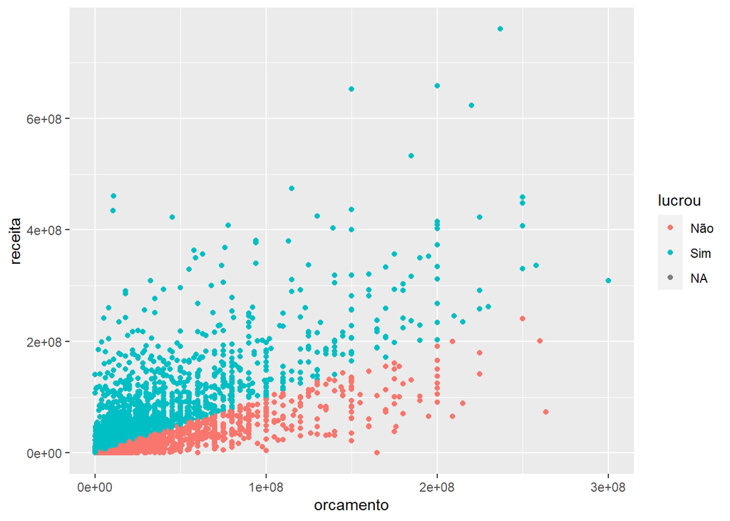

Figura 1. Qtd. de filmes que deram lucro.

```r
imdb %>%
  mutate(lucro = receita - orcamento) %>%
  mutate(lucrou = ifelse(lucro <= 0, "Não", "Sim")) %>%
  ggplot() +
  geom_point(aes(x = orcamento, y = receita, color = lucrou))
```

##### Verificando o gráfico, vimos que a maior parte dos filmes deram lucro e que muitos filmes mesmo com pouco orçamento no fim deram algum tipo de retorno.

## Melhor gênero de filme

```r
imdb %>%
  mutate(lucro=receita-orcamento) %>%
  group_by(generos) %>%
  summarise(media_lucro = mean(lucro, na.rm = TRUE),qtd = n()) %>%
  filter(qtd>15) %>%
  arrange(desc(media_lucro))
```

| generos | media_lucro | qtd |
| --- | --- | --- |
| Adventure\|Animation\|Comedy\|Family\|Fantasy | 54891179 | 26 |
| Adventure\|Animation\|Comedy\|Family | 51139961 | 18 |
| Action\|Comedy\|Crime | 48086749 | 24 |
| Action\|Adventure\|Sci-Fi | 43027809 | 45 |
| Comedy\|Family | 39618862 | 23 |
| Horror\|Mystery | 33873388 | 23 |
| Horror | 33117199 | 55 |
| Biography\|Drama | 27729511 | 23 |
| Crime\|Thriller | 26571986 | 17 |
| Action\|Adventure\|Thriller | 24632768 | 20 |

[output cut: 30 more lines]

##### Vimos que os filmes que trazem uma média com maior lucro são os gêneros: aventura / animação / comédia / família.

## Melhores filmes no genero escolhido

```r
imdb %>%
  mutate(lucro=receita-orcamento) %>%
  filter(generos == "Adventure|Animation|Comedy|Family|Fantasy" | generos == "Adventure|Animation|Comedy|Family") %>%
  group_by(titulo) %>%
  summarise(media_lucro = mean(lucro, na.rm = TRUE), qtd = n()) %>%
  arrange(desc(media_lucro))
```

| titulo | media_lucro | qtd |
| --- | --- | --- |
| Finding Nemo | 286838870 | 1 |
| Toy Story 3 | 214984497 | 1 |
| Shrek | 207652016 | 1 |
| Monsters, Inc. | 174907418 | 1 |
| Toy Story | 161796233 | 1 |
| Shrek the Third | 160706665 | 1 |
| Toy Story 2 | 155823397 | 1 |
| Madagascar | 118136719 | 1 |
| Up | 117979556 | 1 |
| Ice Age | 117387405 | 1 |

[output cut: 34 more lines]

##### Ficou bem nítido que os filmes que trazem maior retorno são os filmes com desenho animado que conseguem atingir praticamente todas as idades e principalmente as crianças que sempre precisam de algum responsável para leva-las.

## Duração de Filmes

```r
imdb %>%
  mutate(lucro=receita-orcamento) %>%
    filter(generos == "Adventure|Animation|Comedy|Family|Fantasy" | generos == "Adventure|Animation|Comedy|Family") %>%
  group_by(duracao) %>%
  summarise(media_lucro = mean(lucro, na.rm = TRUE),qtd = n()) %>%
  arrange(desc(media_lucro))
```

| duracao | media_lucro | qtd |
| --- | --- | --- |
| 100 | 286838870 | 1 |
| 74 | 161796233 | 1 |
| 82 | 155823397 | 1 |
| 90 | 146707019 | 2 |
| 103 | 121662020 | 3 |
| 86 | 118136719 | 1 |
| 93 | 89431892 | 5 |
| 104 | 68488329 | 1 |
| 87 | 55416609 | 1 |
| 96 | 54393598 | 2 |

[output cut: 13 more lines]

##### Apesar de achar que a duração do filme não influencia tanto na escolha, a recomendação seria algo em torno de 100 minutos, para não ficar cansativo para as crianças.

## Classificaçãao Etária

```r
imdb %>%
  mutate(lucro=receita-orcamento) %>%
  group_by(classificacao) %>%
  summarise(media_lucro = mean(lucro, na.rm = TRUE),qtd = n()) %>%
  arrange(desc(media_lucro))
```

| classificacao | media_lucro | qtd |
| --- | --- | --- |
| Livre | 27960527 | 544 |
| Outros | 26661959 | 459 |
| A partir de 13 anos | 18588209 | 1170 |
| A partir de 18 anos | 11138011 | 1540 |

##### A classificação etária que dá mais lucro é a LIVRE.

## Melhores Diretores

```r
imdb %>%
mutate(lucro=receita-orcamento) %>%
group_by(diretor) %>%
summarise(media_lucro = mean(lucro, na.rm = TRUE), qtd = n()) %>%
  filter(qtd>10) %>%
arrange(desc(media_lucro))
```

| diretor | media_lucro | qtd |
| --- | --- | --- |
| Steven Spielberg | 112876558.0 | 24 |
| Michael Bay | 61203625.9 | 12 |
| Tim Burton | 43577038.1 | 14 |
| Robert Zemeckis | 42254546.8 | 13 |
| Shawn Levy | 32904635.3 | 11 |
| Clint Eastwood | 32116900.0 | 20 |
| Francis Ford Coppola | 32040041.9 | 11 |
| Ron Howard | 31832341.0 | 12 |
| Steven Soderbergh | 29245740.6 | 14 |
| Robert Rodriguez | 19334007.7 | 12 |

[output cut: 9 more lines]

##### O melhor Diretor é o Steven Spielberg que é um especialista em filmes de ficção cientifica.

## Melhores Atores

```r
imdb %>%
mutate(lucro=receita-orcamento) %>%
group_by(ator_1) %>%
summarise(media_lucro = mean(lucro, na.rm = TRUE), qtd = n()) %>%
  filter(qtd>5) %>%
arrange(desc(media_lucro))
```

| ator_1 | media_lucro | qtd |
| --- | --- | --- |
| Steve Carell | 97381981.778 | 10 |
| Jennifer Lawrence | 89307571.231 | 14 |
| Harrison Ford | 83671166.520 | 26 |
| Bradley Cooper | 80655022.077 | 13 |
| Macaulay Culkin | 77310856.167 | 6 |
| Lea Thompson | 74768041.250 | 6 |
| Tom Hanks | 71454804.174 | 23 |
| Natalie Portman | 70645876.154 | 13 |
| Matthew Broderick | 59416548.000 | 11 |
| Jada Pinkett Smith | 53076993.167 | 7 |

[output cut: 111 more lines]

##### Os atores que trazem mais retorno são Steve Carell e Jennifer Lawrence.

## Quanto precisariam desembolsar

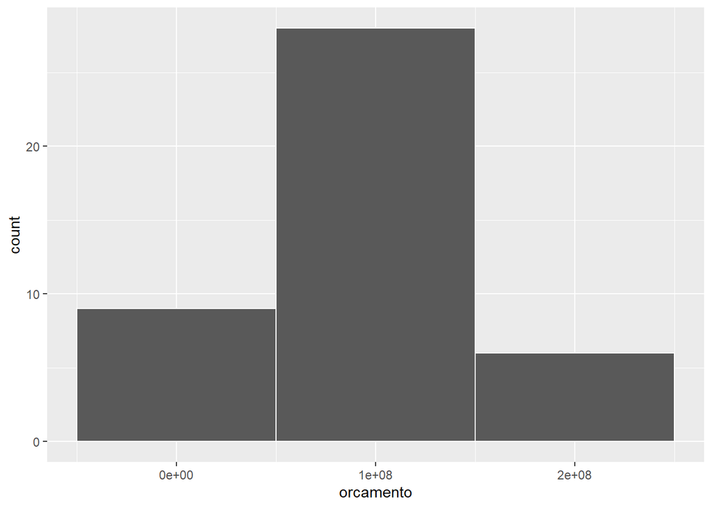

```r
imdb %>%
  filter(generos == "Adventure|Animation|Comedy|Family|Fantasy" | generos == "Adventure|Animation|Comedy|Family") %>%
  ggplot() +
  geom_histogram(
    aes(x = orcamento),
    binwidth = 100000000,
    color = "white"
  )
```

## Conclusão

##### Todas as analises foram feitas em cima do lucro. O futuro investimento no ramo cinematográfico, deve ser feito nas seguintes características:

- Desenho Animado - aventura / animação / comédia / família
- Duração de Filmes - 100 minutos
- Classificação - Etária Livre
- Diretor - Entrar em contato com a produtora que faz animação.
- Ator - Não vai existir gasto com atores e sim com dubladores, dessa forma barateando o orçamento.
- Orçamento - Aproximadamente R$120.000.000